# Curriculum

```r
library(tidyverse)
library(yingtools2)
library(phyloseq)
```

### Basic vector manipulations

Datasets used here: `rivers` (numeric vector), `sentences` (character vector), `state.division` (factor vector), `airquality` (data frame)

| Task | Code |
| --- | --- |
| Length of a vector | `length(rivers)` |
| First element of a vector | `rivers[1]` -or- `first(rivers)` |
| Last element of a vector | `rivers[length(rivers)]` -or- `last(rivers)` |
| Subset by logical condition | `rivers[rivers>700]` |
| Count number of elements that meet a condition | `sum(rivers>700)` |
| Calculate proportion of elements that meet a condition | `mean(rivers>700)` |
| Extract a single column from a data frame | `airquality$Ozone` -or- `airquality[,1]` -or- `airquality[,"Ozone"]` -or- `airquality[["Ozone"]]` -or- `pull(airquality,Ozone)` |
| Test a vector for `NA` values | `is.na(airquality$Ozone)` |
| Sort a variable | `rivers[order(rivers)]` -or- `sort(rivers)` |
| Count the number of distinct values | `length(unique(state.division))` -or- `n_distinct(state.division)` |
| Search for text using regular expressions | `grepl("cat`\|`dog",sentences)` -or- `str_detect(sentences,"cat`\|`dog")` |
| Split a character vector using a separator | `str_split(sentences, pattern=" ")` |
| Tabulate a vector’s values | `tab(state.division)` -or- `table(state.division)` -or- `fct_count(state.division)` |

### Recoding variables

Datasets used here: `state.division` (factor vector)

| Task | Code |
| --- | --- |
| Reorder factor levels based on decreasing frequency | `fct_infreq(state.division)` |
| Reorder factor levels based on another vector | `fct_reorder(state.division,state.area,.fun=sum)` |
| Reorder factor levels based on its current order | `fct_inorder(state.division)` -or- `factor(state.division,levels=unique(state.division))` |
| Collapse less frequent factor levels into “other” | `fct_lump_n(state.division, 4)` |
| Manually recode factor levels | `recode(state.division, "Middle Atlantic"="Mid Atl")` -or- `fct_recode(state.division, "Mid Atl"="Middle Atlantic")` |
| Recode a character based on multiple regular expression criteria (`yingtools2`) | `recode.grep(state.division, recodes=c("central"="Central", "atlantic`\|`new england"="Atlantic"))` |

### Basic data frame manipulations

Datasets used here: `mtcars` (data frame), `band_members` (data frame), `band_instruments` (data frame), `starwars` (data frame), `relig_income` (data frame), `us_rent_income` (data frame)

[output not shown]

### ggplot2 tasks

Dataset used here: `diamonds` (ggplot2 package)

Task

Code

Plot

histogram

`ggplot(diamonds, aes(x = price)) + geom_histogram()`

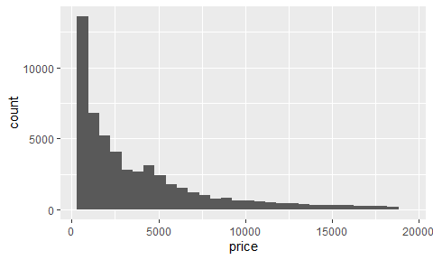

scatterplot

`ggplot(diamonds, aes(x = carat, y = price)) + geom_point()`

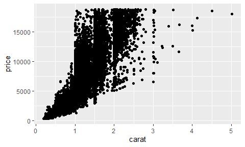

text labels

`ggplot(diamonds, aes(x = carat, y = price, label = color)) + geom_text()`

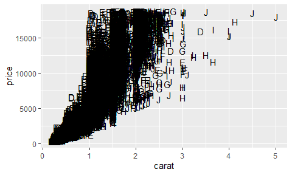

barplot (height count)

`ggplot(diamonds, aes(x = color)) + geom_bar()`

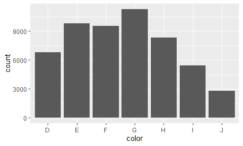

barplot (height manually specified)

`diamonds %>%`  
`count(cut) %>%`  
`ggplot(aes(x = cut, y = n)) + geom_col()`

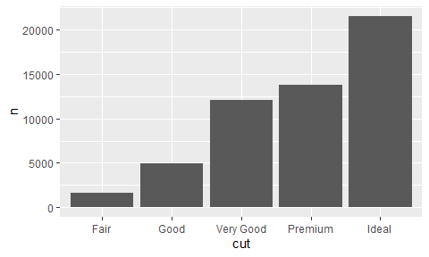

barplot (stacked)

`ggplot(diamonds, aes(x = clarity, fill = cut)) + geom_bar()`

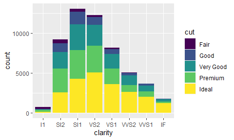

barplot (stacked proportion)

`ggplot(diamonds, aes(x = clarity, fill = cut)) + geom_bar(position = "fill")`

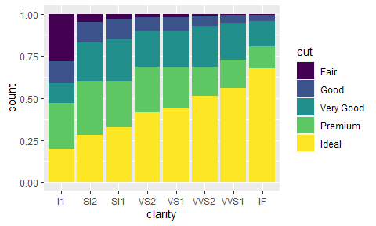

barplot (side-by-side)

`ggplot(diamonds, aes(x = clarity, fill = cut)) + geom_bar(position = "dodge")`

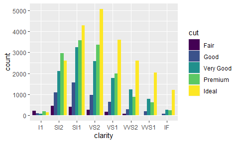

boxplot

`ggplot(diamonds, aes(x = clarity, y = price)) + geom_boxplot()`

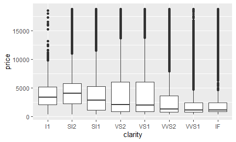

dotplot

`ggplot(diamonds, aes(x = cut, y = price)) + geom_dotplot(binaxis = "y", stackdir = "center", binwidth = 20)`

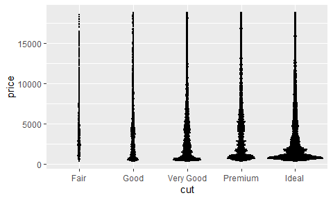

heatmap

`d <- diamonds %>%`  
`count(clarity, color)`  
`ggplot(d, aes(x = clarity, y = color, fill = n)) + geom_tile()`

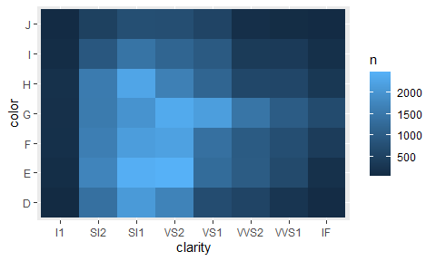

### ggplot2 tasks

Dataset used here: `diamonds` (ggplot2 package)

Task

Code

Plot

Add Title

`gbar + labs(title = "Diamonds", tag = "Fig 1", caption = "N = 53,940")`

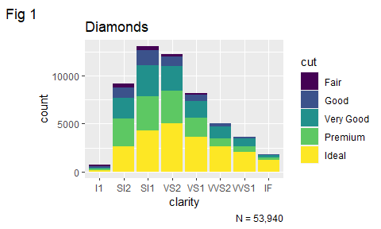

Specify Axis Title

`gbar + scale_x_discrete("Clarity (GIA rated)")`  
`gbar + labs(x = "Clarity (GIA rated)")`  
`gbar + xlab("Clarity (GIA rated)")`

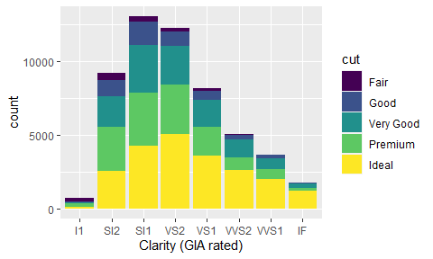

Manually define color palette

`palette <- c(Fair = "red", Good = "blue",`Very Good`= "green", Premium = "#9ba744", Ideal = "#963695")`  
`gbar + scale_fill_manual(values = palette)`

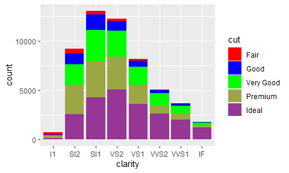

Faceted plot across a group

`gbar + facet_wrap(~color)`

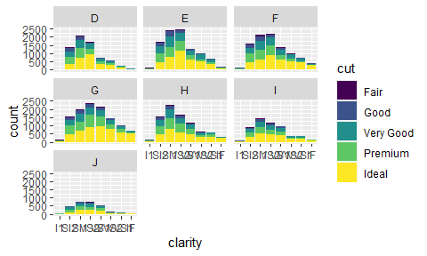

Change Axis Text Characteristics

`gbar + theme(axis.text.x = element_text(size = 20, color = "red", angle = 90))`

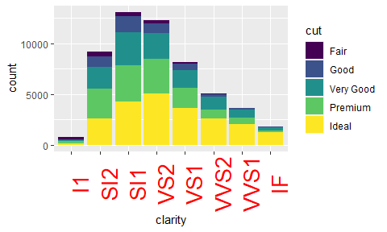

Suppress Axis

`gbar + theme(axis.text.x = element_blank(), axis.title.x = element_blank(), axis.ticks.x = element_blank())`  
`gbar + guides(fill = FALSE)`

[figure not shown]

Alter axis bounds

`gbar + coord_cartesian(ylim = c(0, 35000))`  
`gbar + ylim(0, 35000)`  
`gbar + scale_y_continuous(limits = c(0, 35000))`

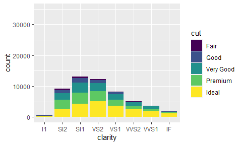

Suppress legend

`gbar + theme(legend.position = "none")`

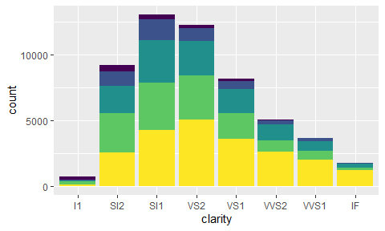

### Phyloseq tasks

Datasets used here: `cid.phy` (yingtools2 package)

| Task | Code |
| --- | --- |
| Get sample data (rows=samples) | `get.samp(cid.phy)` |
| Get sample data and calculate alpha diversity | `get.samp(cid.phy,stats=TRUE)` |
| Get tax table (rows=taxa) | `get.tax(cid.phy)` |
| Get combined long table of tax abundances (rows=samples x taxa) | `get.otu.melt(cid.phy)` |
| Collapse phyloseq by genus level | `phy.collapse(cid.phy,taxranks=c("Superkingdom","Phylum","Class", "Order", "Family", "Genus"))` |
| Subset of samples with liquid consistency | `subset_samples(cid.phy,Consistency=="liquid")` |
| Remove samples with fewer than 1000 seqs | `prune_samples(sample_sums(cid.phy)>=1000,cid.phy)` |